# Econometria

Agustin Riquelme y Heriberto Espino

2023-08-30

# Proyecto 1

#### Agustin Riquelme y Heriberto Espino

Para este modelo de regresión líneal se usó la base de datos lung cap, la cuál recolecta información de un grupo de personas acerca de si son fumadoras o no, las edades respectivas, además de la altura, el género y su FEV(Forced Expiratory Volumen), que mide la habilidad de expedir aire de los pulmones. En este caso, la variable que se tomará como predictora será la edad, sin emabrgo, de igual manera se seccionará en dos, en fumadores y no fumadores para un mejor análisis de los datos.

Para el caso general, donde se opta por juntar ambos grupos sin diferencia, tenemos los siguientes datos estadísticos, donde podemos observar que las personas que fueron parte de esta muestra van desde los 3 hasta los 19 años de edad con un promedio de 10 años y misma mediana, además, la edad que más se repite es de 9 años y además su varianza no difiere mucho de la media.

Edad

| Datos.estadísticos | Valores |
| --- | --- |
| Mínimo | 3.000 |
| Primer cuantil | 8.000 |
| Mediana | 10.000 |
| Media | 9.931 |
| Tercer cuantil | 12.000 |
| Máximo | 19.000 |
| Moda | 9.000 |
| Varianza | 8.726 |
| Desviacion estándar | 2.954 |

| Datos.estadísticos | Valores |
| --- | --- |
| Mínimo | 0.791 |
| Primer cuantil | 1.981 |
| Mediana | 2.547 |
| Media | 2.637 |
| Tercer cuantil | 3.118 |
| Máximo | 5.793 |
| Moda | 3.082 |
| Varianza | 0.752 |
| Desviacion estándar | 0.867 |

Para el casode los fumadores, estos inician a partir de la edad de 9 años y termina en el mismo rango que los datos en conjunto, siendo 19 con un promedio de 14 años pero con 13 años como la cifra más repetida. Y a pesar de no ser mostrado, el porcentaje de fumadores dentro de la base corresponde a 10%.

| Datos.estadísticos | Valores |
| --- | --- |
| Mínimo | 9.000 |
| Primer cuantil | 12.000 |
| Mediana | 13.000 |
| Media | 13.523 |
| Tercer cuantil | 15.000 |
| Máximo | 19.000 |
| Moda | 13.000 |
| Varianza | 5.472 |
| Desviacion estándar | 2.339 |

Para el caso del índice FEV, el mínimo corresponde a 1.7 mientras que el máximo a 4.8, teniendo una media por encima de los datos totales sin embargo una varianza menor.

| Datos.estadísticos | Valores |
| --- | --- |
| Mínimo | 1.694 |
| Primer cuantil | 2.795 |
| Mediana | 3.169 |
| Media | 3.277 |
| Tercer cuantil | 3.751 |
| Máximo | 4.872 |
| Moda | 3.297 |
| Varianza | 0.562 |
| Desviacion estándar | 0.750 |

Ahora para el caso de los no fumadores, la edad más pequeña registrada es de 3 años, mientras que la máxima de igual manera corresponde a la máxima conjunta, en este caso, la media es menor, de 9 años al igual que su moda y mediana. Estos datos tienen una mayor varianza que los fumadores pero menor a la conjunta.

| Datos.estadísticos | Valores |
| --- | --- |
| Mínimo | 3.000 |
| Primer cuantil | 8.000 |
| Mediana | 9.000 |
| Media | 9.535 |
| Tercer cuantil | 11.000 |
| Máximo | 19.000 |
| Moda | 9.000 |
| Varianza | 7.511 |
| Desviacion estándar | 2.741 |

En el caso del índice FEV, se registró un mínimo de 0.8 y un máximo de 5.8. mayor que el caso de los fumadores. Sin embargo, los demás valores parecen ser más pequeños que los datos de fumadores, por lo que analizarlo de esta manera en conjunto y de dos grupos podrá determinar si el fumar tiene alguna consecuencia en este índice al igual que la edad.

| Datos.estadísticos | Valores |
| --- | --- |
| Mínimo | 0.791 |
| Primer cuantil | 1.920 |
| Mediana | 2.465 |
| Media | 2.566 |
| Tercer cuantil | 3.048 |
| Máximo | 5.793 |
| Moda | 1.624 |
| Varianza | 0.723 |
| Desviacion estándar | 0.851 |

Entonces, para un mejor análisis, a partir de este momento, los datos serán seccionados en dos grupos: fumadores y no fumadores. En el primer caso, tendremos los siguientes histogramas y boxplot para el caso de las edades y su índice FEV. Visualmente no observamos ningún outlier en los datos, y no parece haber un comportamiento similar a una distribución normal.

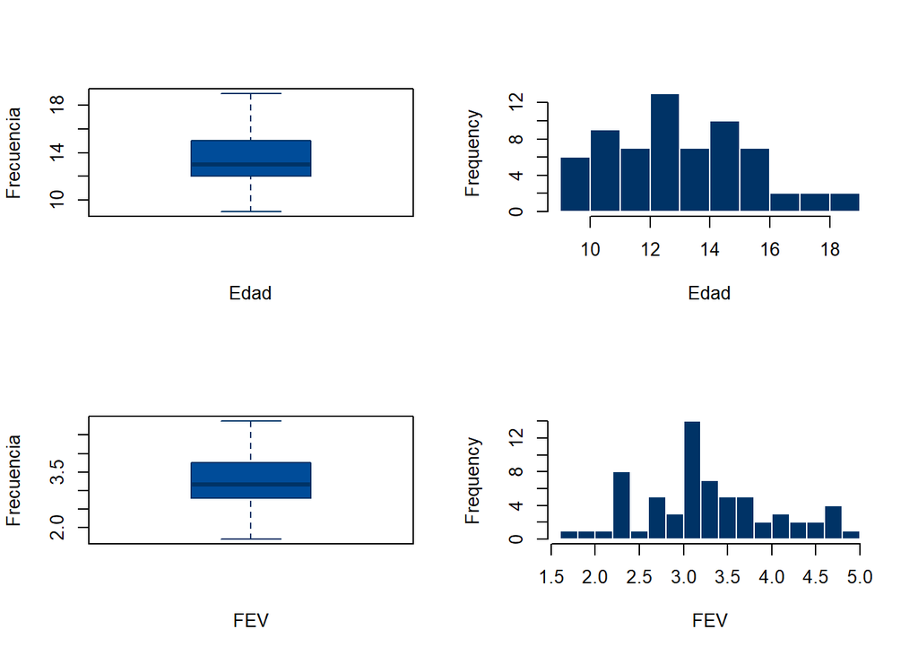

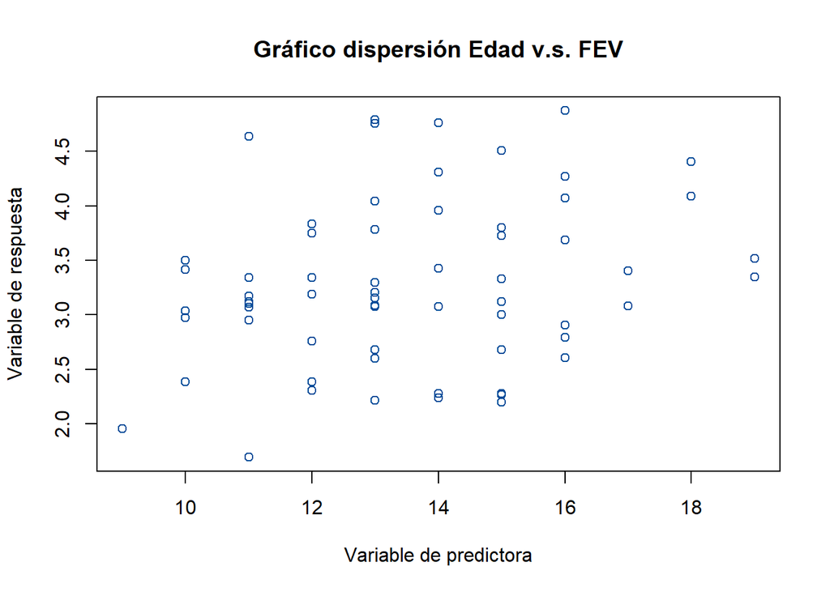

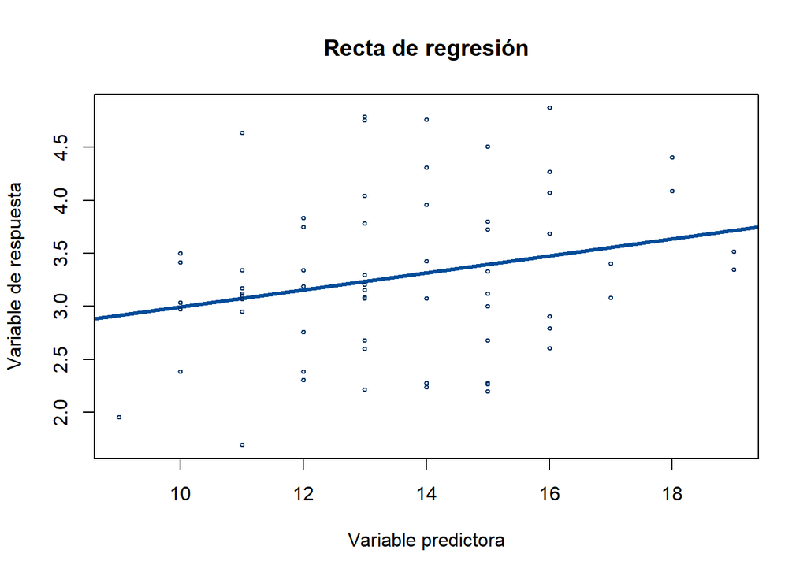

Como podemos observar, la recta de regresión pasa casi al centro de la nube de puntos dispersos, dicha relación puede ser vista de manera más fácil a través de un gráfico de dispersión donde incluyamos el FEV promedio por edad, el cuál es una medida más precisa para poder describir el impacto de la edad sobre este índice, podemos observarlo a continuación:

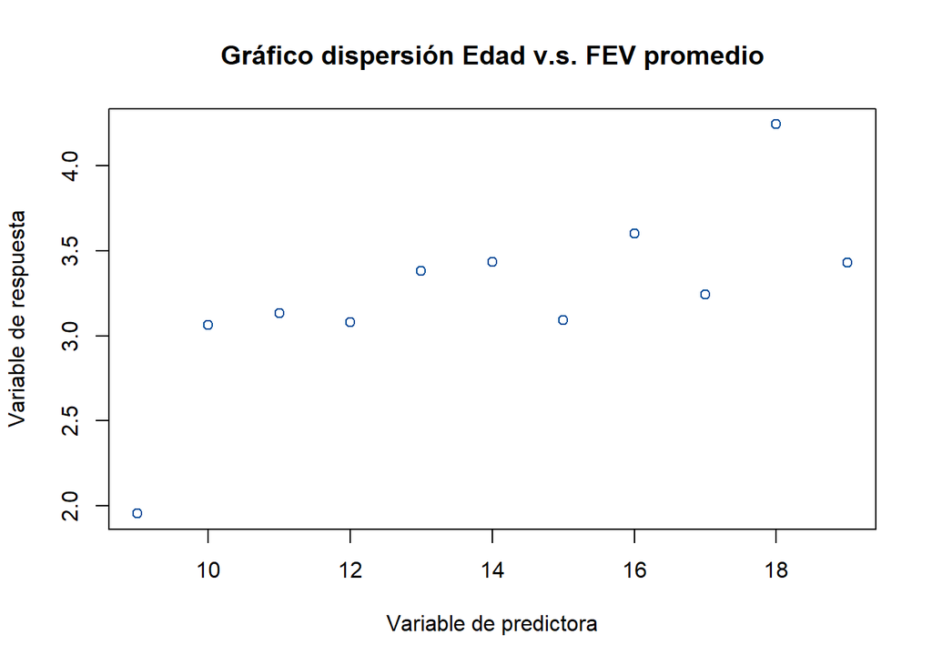

De esta otra manera, con el manejo del promedio de FEV por edad, se puede observar intuitivamente de una mejor manera la forma de la recta de regresión, pudiendo suponer que tiene relación positiva y con una pendiente menor a 1. Además podemos observar un posible outlier a la edad de 9 años, por lo que realizaremos de nuevo un boxplot para su análisis.

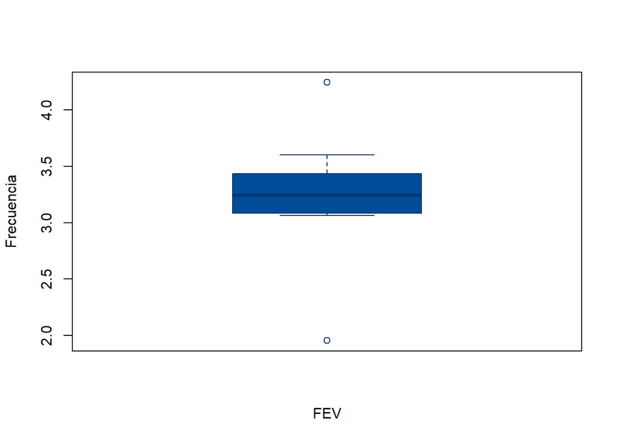

Aquí podemos observar dos outliers en los datos al sacar su FEV promedio respecto a su edad, sin embargo, podemos ver menos dispersos los datos para una mejor aproximación líneal que minimice la distancia entre todos los puntos y por ende los errores totales, esto se verá a continuación:

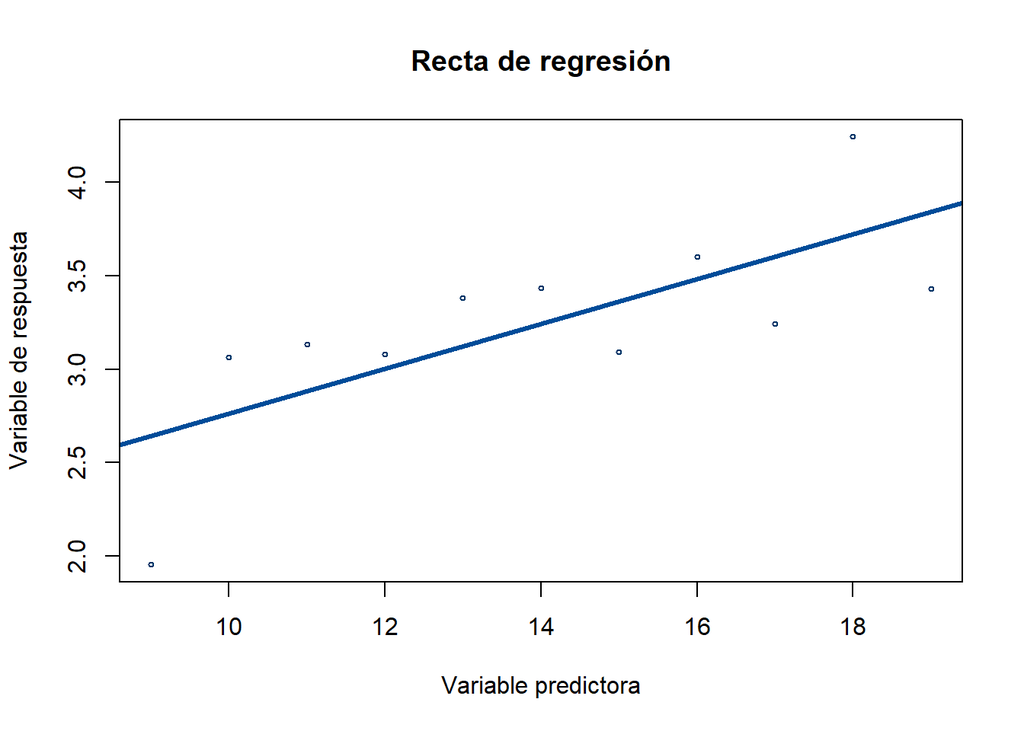

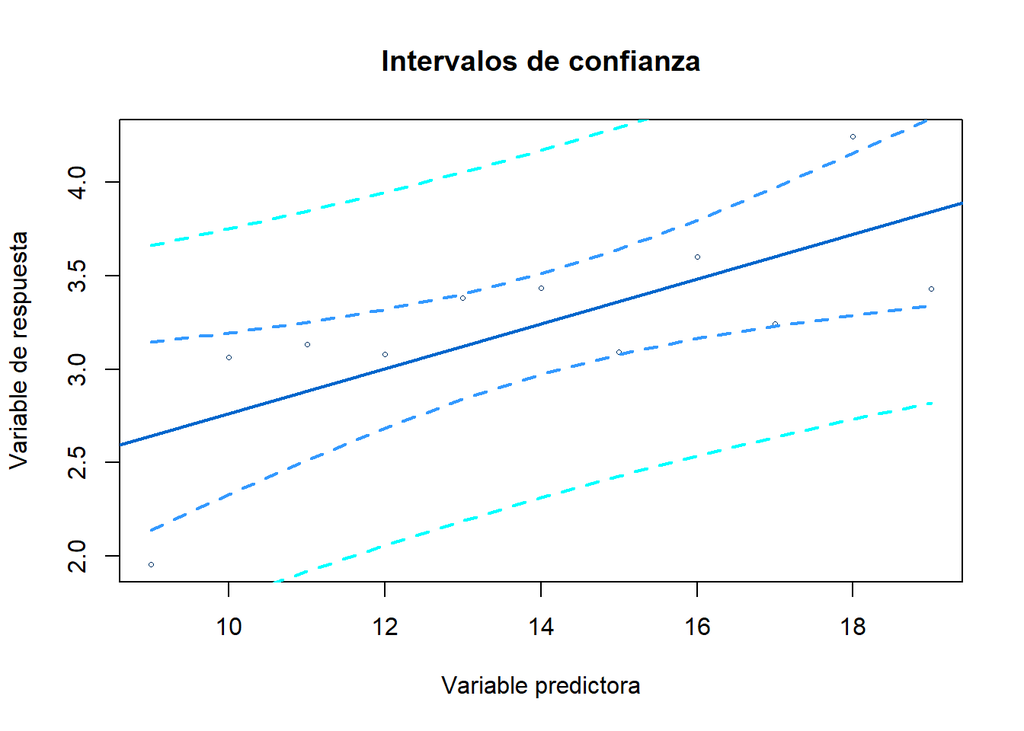

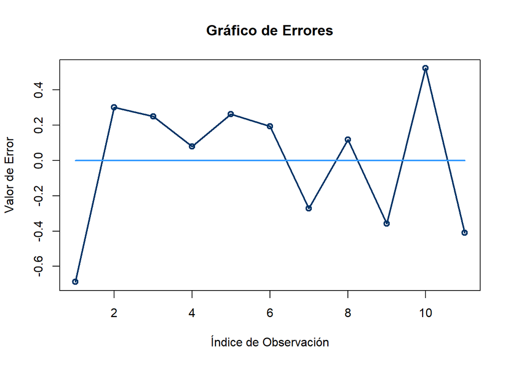

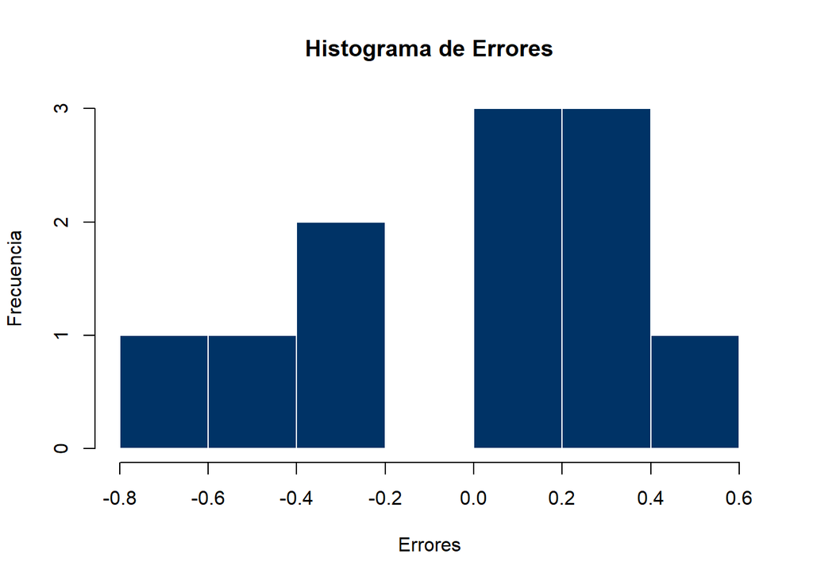

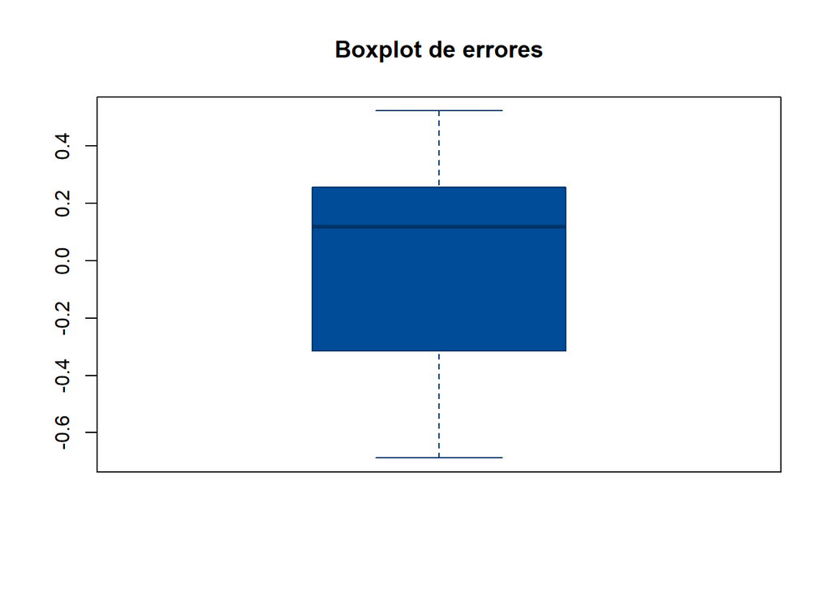

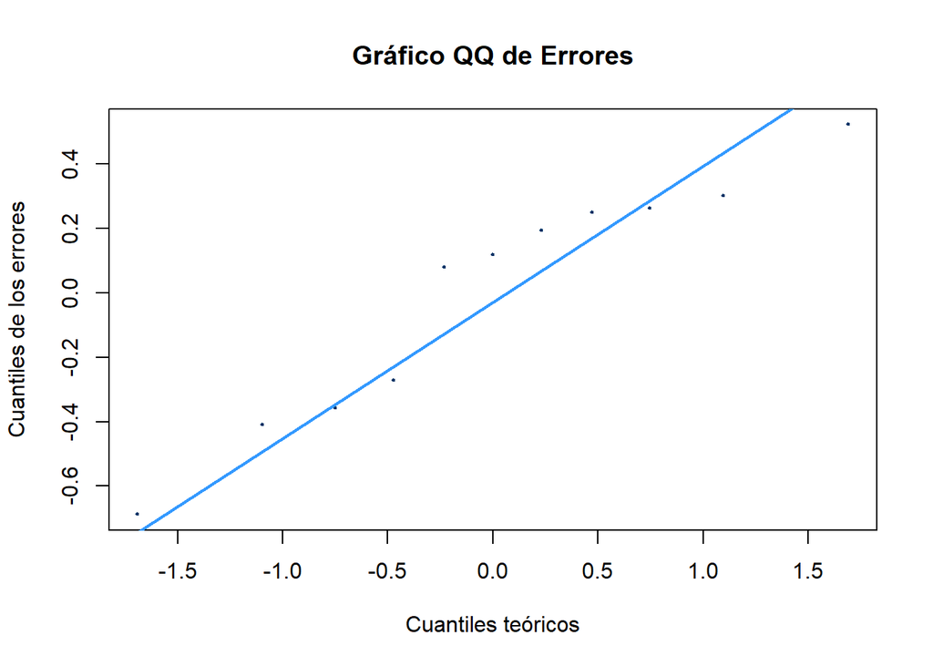

Informacion del modelo

| Datos | Valores |
| --- | --- |
| α | 0.05 |
| β0 | 1.560257005217 |
| β1 | 0.120099224109224 |
| S | 0.393903024150109 |
| S^2 | 0.155159592434601 |
| CV | 12.1513270358503 |
| df | 9 |
| qti | -2.2621571627982 |
| qtd | 2.2621571627982 |
| tc | 3.19777003936184 |
| P valor | 0.010870134685864 |
| Mín. β1 | 0.0351389809644712 |
| Máx. β1 | 0.205059467253977 |
| Prom. err. | -3.5325278056255e-17 |
| Var. error | 0.139643633191141 |
| Shap. P valor | 0.366242866344028 |
| Anderson P valor | 0.218479236573656 |
| Rho Pearson | 0.729299260696424 |
| Rho Spearman | 0.772727272727273 |
| dw | 2.35620794814095 |

Inferencia para β1 H0: β1 = 0 vs H1: β1 ≠ 0

| Prueba.de.hipótesis | Conclusión |
| --- | --- |
| tc | Rechazamos H0. β1 ≠ 0 |
| p valor | Rechazamos H0. β1 ≠ 0 |

Coeficiente de correlación

| Rho | Conclusión |
| --- | --- |
| Pearson | Hay una correlación fuerte |
| Spearman | Hay una correlación fuerte |

Test de normalidad H0: Los datos son normales vs H1: Los datos no son normales

| Test.de.normalidad | Valor |
| --- | --- |
| Normalidad Shapiro | pvalor ≥ α, no rechazamos H0 |
| Normalidad Anderson | pvalor ≥ α, no rechazamos H0 |

Test Durbin-Watson

| Test | Conclusión |
| --- | --- |
| dw | No hay una correlación en los residuos |

Para el caso de los no fumadores, tendremos muchos más outliers para casos de la edad como del FEV, esto podría ser esperado al saber que la mayoría de los datos se concentra en este grupo de no fumadores. Lo que sí podemos observar es que en el histograma ambos datos parecen tener un sesgo a la derecha.

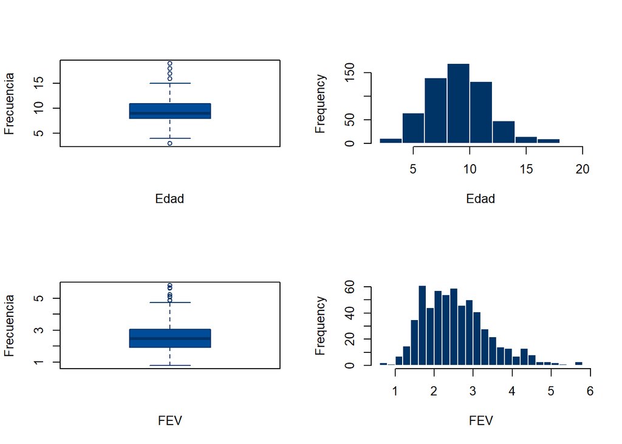

De igual manera que para el caso anterior, los datos están bastantes dispersos y si bien la gráfica de la línea de regresión se encuentra en un punto medio de la nube de puntos, para que sea mejor aproximada, se sacará el promedio del índice por edad y así se obtendrá un número de puntos según el número de edades.

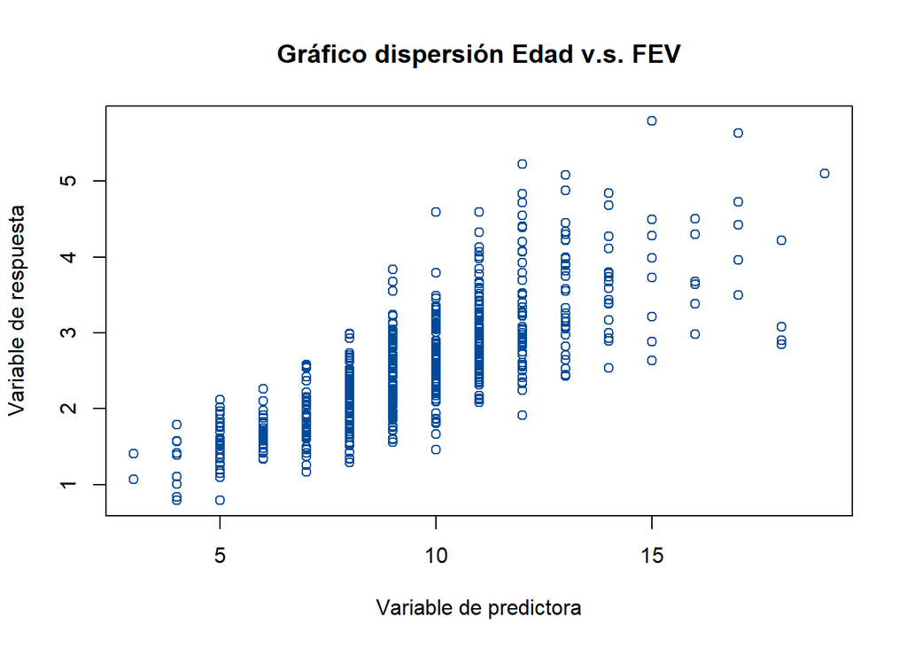

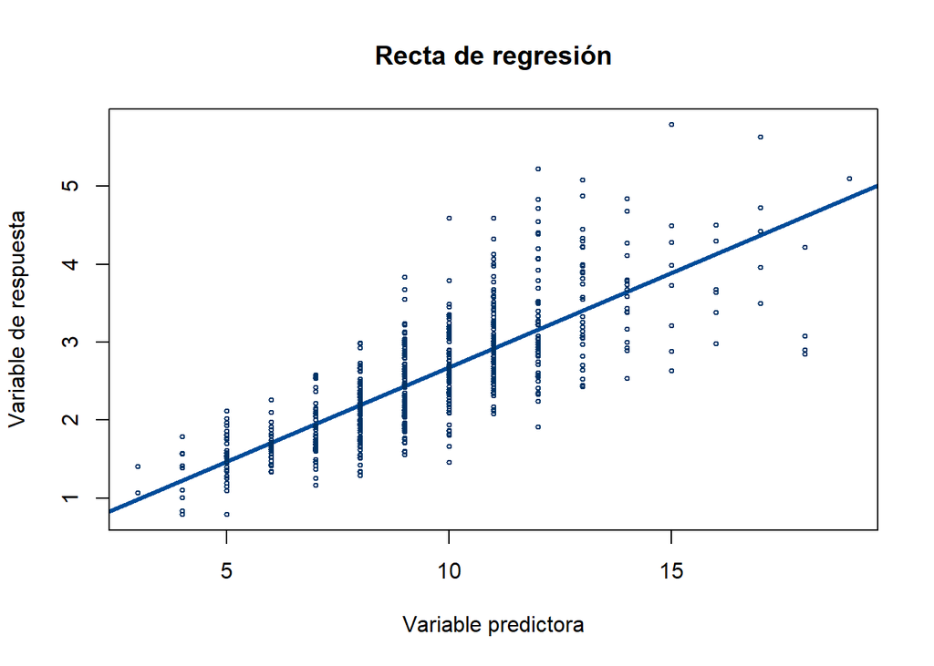

Aquí los puntos se encuentran mucho mejor posicionados para una mejor interpretación gráfica donde sí vemos una relación positiva entre las variables, incluso de mejor manera que el caso anterior.

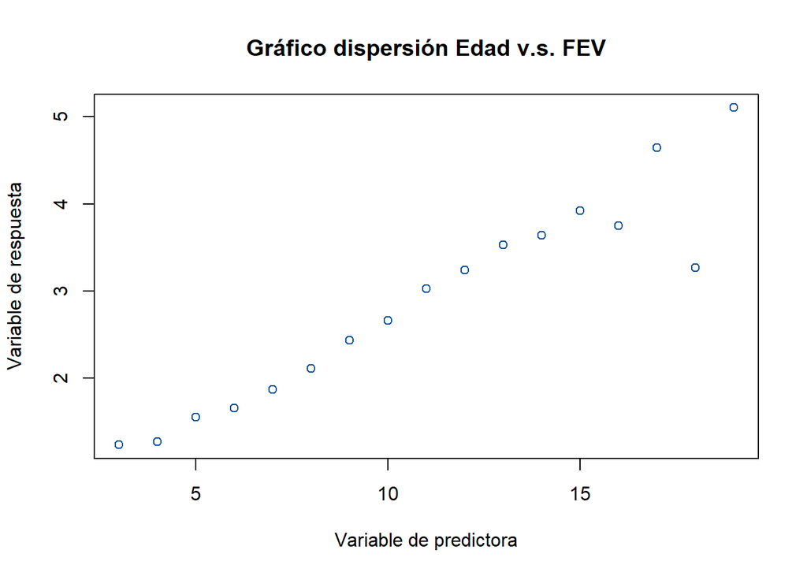

Al tener un entorno mucho más limpio, el análisis es más sencillo y podemos observar que estos datos se comportan mucho más como la línea de regresión a excepción de dos puntos, lo que podría indicar que los errores de este modelo podrían ser menores que el anterior y sugiriendo que el fumar pueda alterar los resultados normales a los que se debería de comportar el índice FEV según la edad.

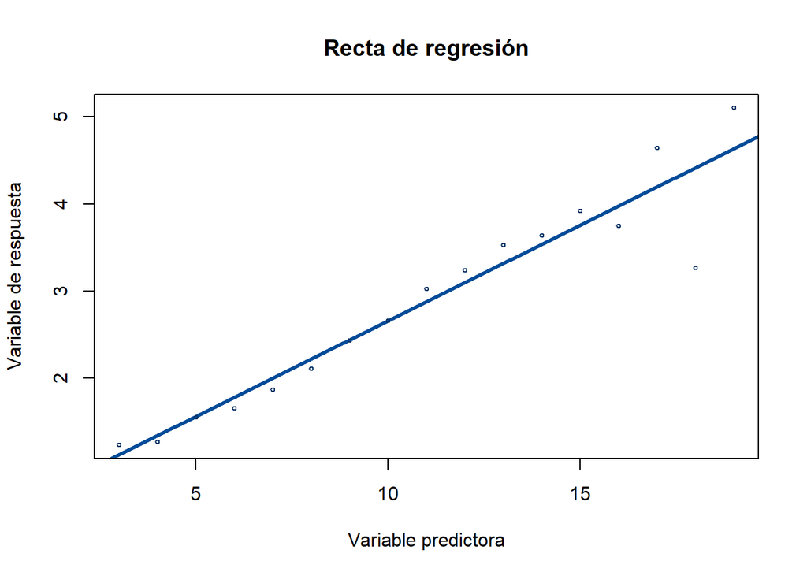

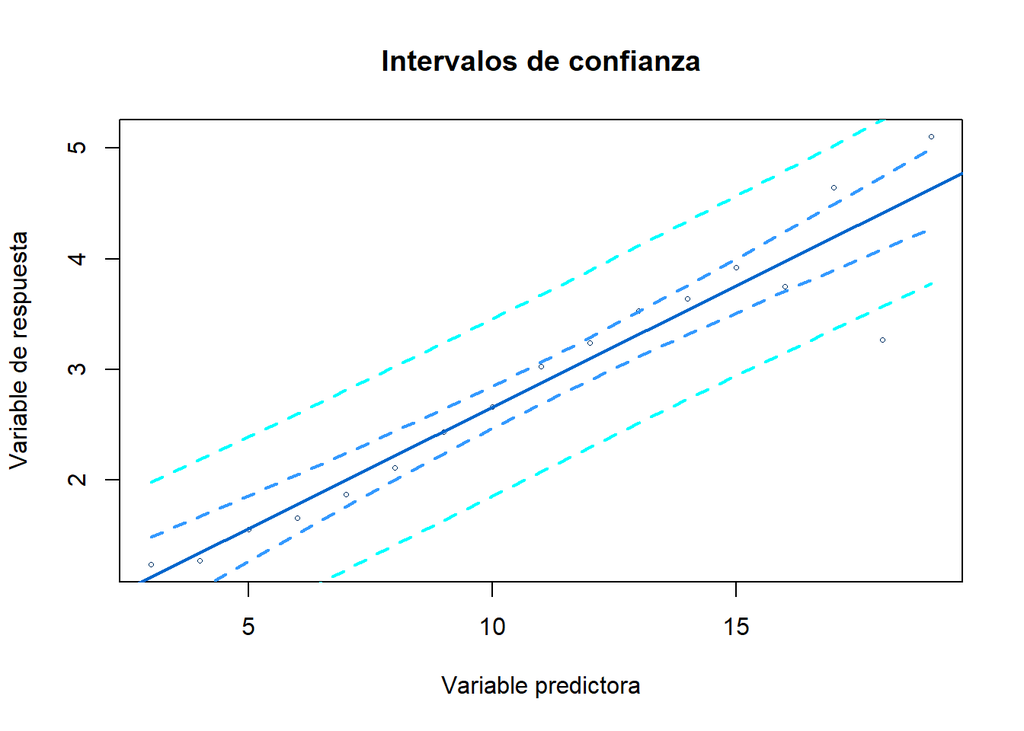

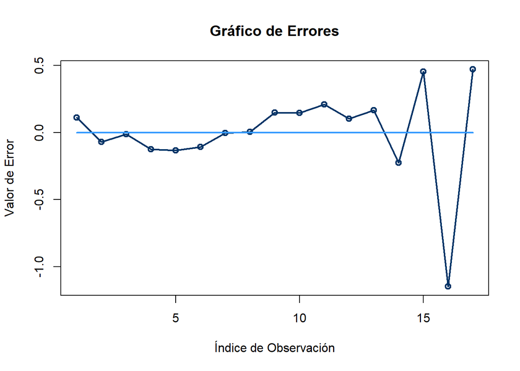

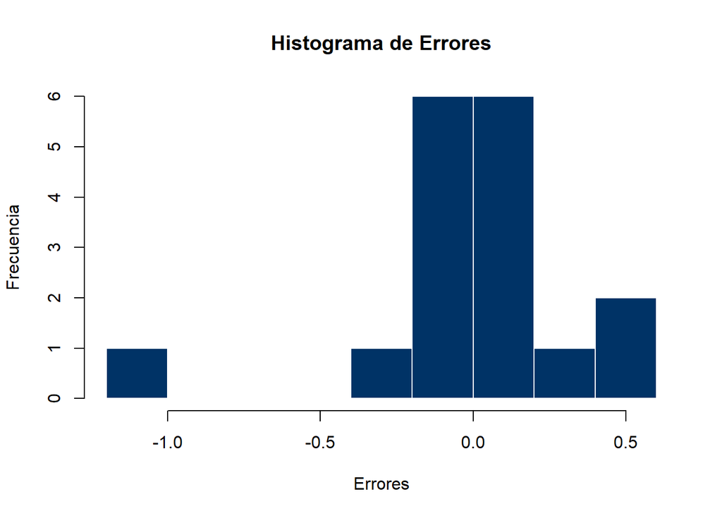

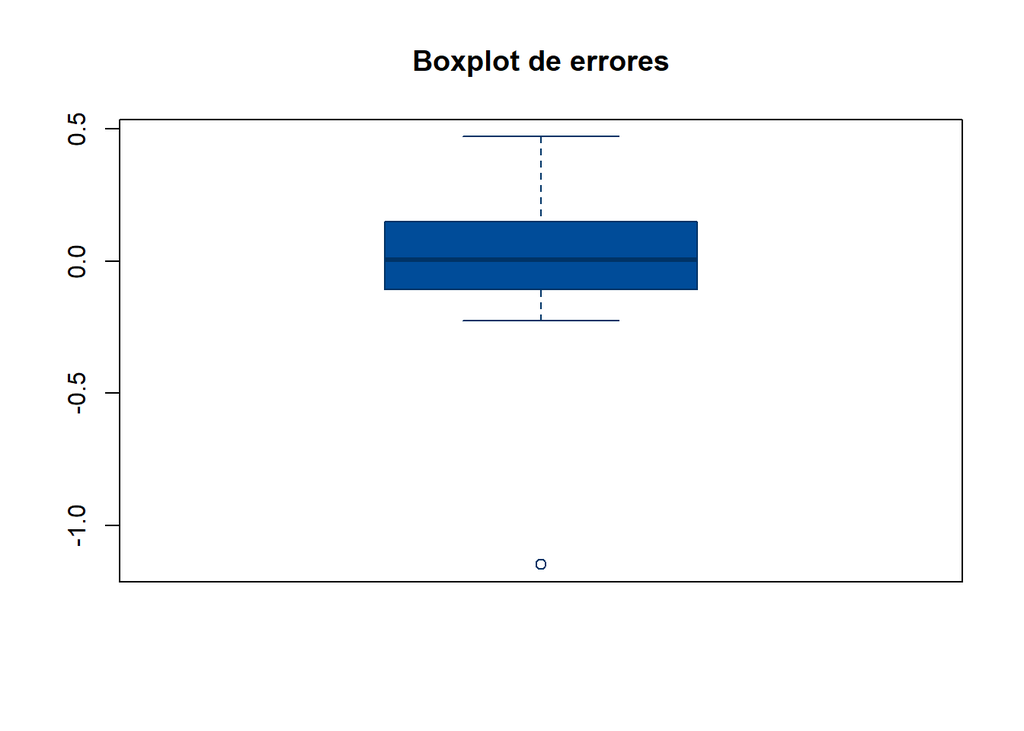

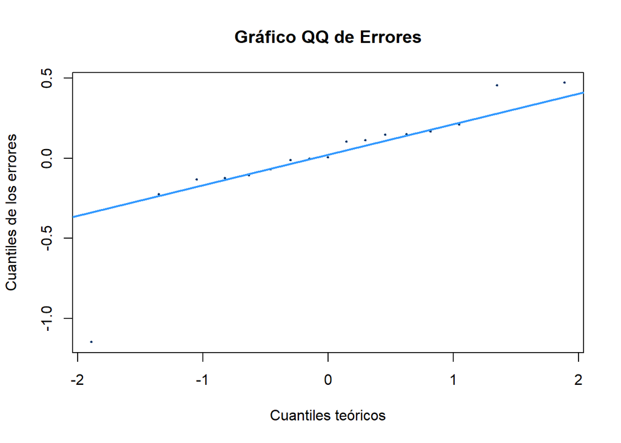

Informacion del modelo

| Datos | Valores |
| --- | --- |
| α | 0.05 |
| β0 | 0.468252357996954 |
| β1 | 0.219122650140799 |
| S | 0.363613080465725 |
| S^2 | 0.132214472285774 |
| CV | 12.6315879172559 |
| df | 15 |
| qti | -2.13144954555978 |
| qtd | 2.13144954555978 |
| tc | 12.1724459657473 |
| P valor | 0.00000000355599872489347 |
| Mín. β1 | 0.180753297392903 |
| Máx. β1 | 0.257492002888695 |
| Prom. err. | -0.0000000000000000289848695494323 |
| Var. error | 0.123951067767913 |
| Shap. P valor | 0.00124135991555556 |
| Anderson P valor | 0.0035356766036633 |
| Rho Pearson | 0.952927310022899 |
| Rho Spearman | 0.96078431372549 |
| dw | 2.97416176068524 |

Inferencia para β1 H0: β1 = 0 vs H1: β1 ≠ 0

| Prueba.de.hipótesis | Conclusión |
| --- | --- |
| tc | Rechazamos H0. β1 ≠ 0 |
| p valor | Rechazamos H0. β1 ≠ 0 |

Coeficiente de correlación

| Rho | Conclusión |
| --- | --- |
| Pearson | Hay una correlación fuerte |
| Spearman | Hay una correlación fuerte |

Test de normalidad H0: Los datos son normales vs H1: Los datos no son normales

| Test.de.normalidad | Valor |
| --- | --- |
| Normalidad Shapiro | pvalor < α, rechazamos H0. No son normales |
| Normalidad Anderson | pvalor < α, rechazamos H0. No son normales |

Test Durbin-Watson

[output not shown]